[output not shown]

# Intro

In this tutorial we will continue working with the **German Credit Dataset**. We already used different `Learner`s on it and tried to optimize their hyperparameters. Now we will

- preprocess the data as an integrated step of the model fitting process
- tune the preprocessing parameters
- use multiple `Learners` in an *ensemble* model
- see some techniques that make `Learner`s able to tackle challenging datasets that they could not handle otherwise.

# Prerequisites

```r
library("data.table")
library("mlr3")
library("mlr3learners")
library("ggplot2")
theme_set(theme_light())
library("mlr3tuning")
```

We use the same data as before. but will restrict ourselves to the *numerical features*. To make things interesting, we introduce *missing values* in the dataset.

```r
credit_full = readRDS("credit.rds")
credit = credit_full[, sapply(credit_full, is.numeric), with = FALSE]
set.seed(20191101)
# turn 10% of values into an NA
credit = credit[, lapply(.SD, function(x)
  x[sample(c(TRUE, NA), length(x), replace = TRUE, prob = c(.9, .1))])]
credit$class = credit_full$class
task = TaskClassif$new("GermanCredit", credit, "class")

task$head()
```

```
#>    class age credit_amount duration existing_credits installment_commitment num_dependents residence_since
#> 1:  good  67          1169        6                2                      4              1               4
#> 2:   bad  22          5951       48                1                      2              1              NA
#> 3:  good  49          2096       12                1                      2              2              NA
#> 4:  good  45          7882       42                1                      2              2               4
#> 5:   bad  53          4870       24                2                      3              2               4
#> 6:  good  35            NA       36                1                      2              2               4
```

- We instantiate a resampling instance for this task to be able to compare resampling performance.

```r
set.seed(20191101)
cv10_instance = rsmp("cv")$instantiate(task)
```

Uncomment the following line if you are running this locally (i.e. not on RStudio Cloud).

```r
# future::plan("multiprocess")
```

# Intro

In this tutorial we will take a look at composite machine learning algorithms that may incorporate data preprocessing or the combination of multiple `Learner`s (“ensemble methods”).

- The package we use is **mlr3pipelines**, which enables us to chain “`PipeOp`” objects into data flow graphs. Load the package using

```r
library("mlr3pipelines")
```

- Available `PipeOp`s are enumareted in the `mlr_pipeops` dictionary.

```r
mlr_pipeops
```

```
#> <DictionaryPipeOp> with 42 stored values
#> Keys: boxcox, branch, chunk, classbalancing, classifavg, classweights, colapply, collapsefactors,
#>   copy, encode, encodeimpact, encodelmer, featureunion, filter, fixfactors, histbin, ica,
#>   imputehist, imputemean, imputemedian, imputenewlvl, imputesample, kernelpca, learner,
#>   learner_cv, missind, modelmatrix, mutate, nop, pca, quantilebin, regravg, removeconstants,
#>   scale, scalemaxabs, scalerange, select, smote, spatialsign, subsample, unbranch, yeojohnson
```

# Missing Value Imputation

- Trying to train a Random Forest fails because the model can not handle missing values.

```r
ranger = lrn("classif.ranger")

ranger$train(task)
```

```
#> Error: Missing data in columns: age, credit_amount, duration, existing_credits, installment_commitment, num_dependents, residence_since.
```

- We can impute using a `PipeOp`. What are the imputation `PipeOp`s?

```r
mlr_pipeops$keys("^impute")
```

```
#> [1] "imputehist"   "imputemean"   "imputemedian" "imputenewlvl" "imputesample"
```

```r
imputer = po("imputemean")

task_imputed = imputer$train(list(task))[[1]]

task_imputed$head()  # no missing values
```

```
#>    class age credit_amount duration existing_credits installment_commitment num_dependents residence_since
#> 1:  good  67      1169.000        6                2                      4              1        4.000000
#> 2:   bad  22      5951.000       48                1                      2              1        2.846154
#> 3:  good  49      2096.000       12                1                      2              2        2.846154
#> 4:  good  45      7882.000       42                1                      2              2        4.000000
#> 5:   bad  53      4870.000       24                2                      3              2        4.000000
#> 6:  good  35      3285.826       36                1                      2              2        4.000000
```

```r
imputer$state$model
```

```
#> $age
#> [1] 35.54994
#>
#> $credit_amount
#> [1] 3285.826
#>
#> $duration
#> [1] 20.86712
#>
#> $existing_credits
#> [1] 1.40708
#>
#> $installment_commitment
#> [1] 2.956757
#>
#> $num_dependents
#> [1] 1.163934
#>
#> $residence_since
#> [1] 2.846154
```

- If we used the imputed task for resampling, we would leak information from the test set into the training set. Therefore it is mandatory to attach the imputation operator to the `Learner` itself, creating a `GraphLearner`.

```r
imp_ranger = GraphLearner$new(po("imputemean") %>>% ranger)

imp_ranger$train(task)  # runs without error: training succeeds
```

- This can be used for resampling.

```r
rr = resample(task, imp_ranger, cv10_instance)
rr$aggregate()
```

```
#> classif.ce
#>       0.29
```

# Feature Filtering

- Sometimes having fewer features is desirable (interpretability, cost of acquiring data, possibly even better performance)
- Use *feature filter* to preferentially keep features with most information

```r
library("mlr3filters")
mlr_filters
```

```
#> <DictionaryFilter> with 16 stored values
#> Keys: anova, auc, carscore, cmim, correlation, disr, importance, information_gain, jmi, jmim,
#>   kruskal_test, mim, mrmr, njmim, performance, variance
```

- We use the `"anova"` filter. It uses an F-test for values in different target classes (equivalent to a t-test in the binary classification case).

```r
filter = flt("anova")

filter$calculate(task_imputed)$scores
```

```
#>               duration          credit_amount                    age installment_commitment
#>            10.01533574             5.70482677             2.13445606             1.19491184
#>       existing_credits         num_dependents        residence_since
#>             0.69086068             0.07923952             0.02321598
```

- What is the tradeoff between features and performance? Let’s find out by tuning.
- We incorporate our filtering in the pipeline using the `"filter"` `PipeOp`
- We remember that we also need to do imputation.

```r
fpipe = po("imputemean") %>>% po("filter", filter, filter.nfeat = 3)

fpipe$train(task)[[1]]$head()
```

```
#>    class age credit_amount duration
#> 1:  good  67      1169.000        6
#> 2:   bad  22      5951.000       48
#> 3:  good  49      2096.000       12
#> 4:  good  45      7882.000       42
#> 5:   bad  53      4870.000       24
#> 6:  good  35      3285.826       36
```

- We are going to tune over the `anova.filter.nfeat` parameter; it regulates how many features are kept by the filter.

```r
library("paradox")
searchspace = ParamSet$new(list(
  ParamInt$new("anova.filter.nfeat", lower = 1, upper = length(task$feature_names))
))
```

- Because this is only one parameter, we will use grid search. For higher dimensions, random search is more appropriate.

```r
inst = TuningInstance$new(
  task, fpipe %>>% lrn("classif.ranger"), cv10_instance, msr("classif.ce"),
  searchspace, term("none")
)
tuner = tnr("grid_search")
```

- Tuning may take a while…

```r
tuner$tune(inst)
```

- If we plot the performance over the number of features, we see the possible tradeoffs between sparsity and predictive performance.

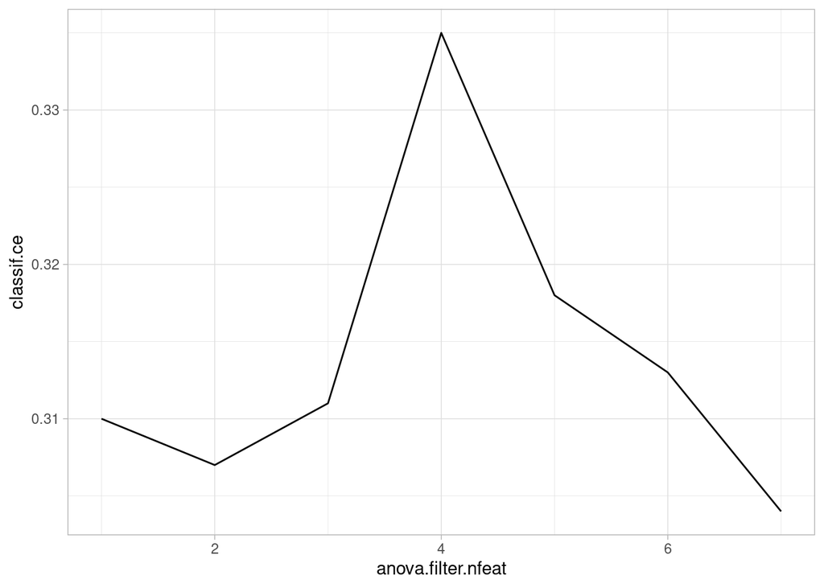

```r
arx = inst$archive("params")
ggplot(arx, aes(x = anova.filter.nfeat, y = classif.ce)) + geom_line()
```

# Stacking

- We build a model on the predictions of learners
- This needs the `"learner_cv"` PipeOp, because predictions need to be available during training already
  - the `"learner_cv"` PipeOp performs crossvalidation during the training phase and emits the cross validated predictions.
- We use `"prob"` prediction because it carries more information than response prediction

```r
stackgraph = po("imputemean") %>>%
  list(
    po("learner_cv", lrn("classif.ranger", predict_type = "prob")),
    po("learner_cv", lrn("classif.kknn", predict_type = "prob"))) %>>%
  po("featureunion") %>>% lrn("classif.log_reg")
```

- What does this `Graph` look like? We can plot it!

```r
stackgraph$plot(html = TRUE)
```

[interactive chart not shown]

```r
rr = resample(task, stackgraph, cv10_instance, store_model = TRUE)
rr$aggregate()
```

```
#> classif.ce
#>      0.295
```

- Compare this to performance of individual `Learner`s. Note, however, that the difference is smaller than the variation in CV estimate.

```r
bmr = benchmark(data.table(task = list(task),
  learner = list(GraphLearner$new(po("imputemean") %>>% lrn("classif.ranger")),
    GraphLearner$new(po("imputemean") %>>% lrn("classif.kknn")),
    GraphLearner$new(po("imputemean") %>>% lrn("classif.log_reg"))),
  resampling = list(cv10_instance)))
bmr$aggregate()[, c("learner_id", "classif.ce")]
```

```
#>                    learner_id classif.ce
#> 1:  imputemean.classif.ranger      0.306
#> 2:    imputemean.classif.kknn      0.352
#> 3: imputemean.classif.log_reg      0.299
```

- If we train the stacked `Learner` and look into the model, we can see how “important” each of the stacked models is

```r
stackgraph$train(task)
```

```r
summary(stackgraph$pipeops$classif.log_reg$state$model)
```

```
#>
#> Call:
#> stats::glm(formula = task$formula(), family = "binomial", data = task$data())
#>
#> Deviance Residuals:
#>     Min       1Q   Median       3Q      Max
#> -1.5134  -0.8348  -0.6877   1.1821   2.0276
#>
#> Coefficients: (2 not defined because of singularities)
#>                          Estimate Std. Error z value Pr(>|z|)
#> (Intercept)                1.2893     0.3304   3.902 9.54e-05 ***
#> classif.ranger.prob.good  -4.1562     0.5376  -7.731 1.07e-14 ***
#> classif.ranger.prob.bad        NA         NA      NA       NA
#> classif.kknn.prob.good     0.9597     0.3451   2.781  0.00542 **
#> classif.kknn.prob.bad          NA         NA      NA       NA
#> ---
#> Signif. codes:  0 '***' 0.001 '**' 0.01 '*' 0.05 '.' 0.1 ' ' 1
#>
#> (Dispersion parameter for binomial family taken to be 1)
#>
#>     Null deviance: 1221.7  on 999  degrees of freedom
#> Residual deviance: 1157.0  on 997  degrees of freedom
#> AIC: 1163
#>
#> Number of Fisher Scoring iterations: 4
```

- The Random Forest (`ranger`) contributes more to the outcome, as one would expect, because it is generally a stronger model.

# Robustify: Preventing new Prediction Factor Levels and other Problems

- Let’s shift contexts: We take the full German Credit dataset.

```r
credit = readRDS("credit.rds")
task = TaskClassif$new("GermanCredit", credit, "class")

task$head()
```

```
#>    class age checking_status credit_amount                 credit_history duration employment
#> 1:  good  67              <0          1169 critical/other existing credit        6        >=7
#> 2:   bad  22        0<=X<200          5951                  existing paid       48     1<=X<4
#> 3:  good  49     no checking          2096 critical/other existing credit       12     4<=X<7
#> 4:  good  45              <0          7882                  existing paid       42     4<=X<7
#> 5:   bad  53              <0          4870             delayed previously       24     1<=X<4
#> 6:  good  35     no checking          9055                  existing paid       36     1<=X<4
#>    existing_credits foreign_worker  housing installment_commitment                job num_dependents
#> 1:                2            yes      own                      4            skilled              1
#> 2:                1            yes      own                      2            skilled              1
#> 3:                1            yes      own                      2 unskilled resident              2
#> 4:                1            yes for free                      2            skilled              2
#> 5:                2            yes for free                      3            skilled              2
#> 6:                1            yes for free                      2 unskilled resident              2
#>    other_parties other_payment_plans own_telephone    personal_status property_magnitude             purpose
#> 1:          none                none           yes        male single        real estate            radio/tv
#> 2:          none                none          none female div/dep/mar        real estate            radio/tv
#> 3:          none                none          none        male single        real estate           education
#> 4:     guarantor                none          none        male single     life insurance furniture/equipment
#> 5:          none                none          none        male single  no known property             new car
#> 6:          none                none           yes        male single  no known property           education
#>    residence_since   savings_status
#> 1:               4 no known savings
#> 2:               2             <100
#> 3:               3             <100
#> 4:               4             <100
#> 5:               4             <100
#> 6:               4 no known savings
```

- When training with a small datasset, or datasets with many factor levels, it is possible that not all possible factor levels are visible to the `Learner` during training. Prediction then fails because the `Learner` does not know how to handle unseen factor levels.

```r
logreg = lrn("classif.log_reg")
logreg$train(task$clone()$filter(1:30))
logreg$predict(task)
```

```
#> Error in model.frame.default(Terms, newdata, na.action = na.action, xlev = object$xlevels): factor job has new levels unemp/unskilled non res
```

- Many `Learner`s can not handle new levels during prediction $\Rightarrow$ we use the `"fixfactors"` `PipeOp` to prevent that
- `"fixfactors"` introduces `NA` values; we may need to impute afterwards.
  - $\Rightarrow$ We use `"imputesample"`, but with `affect_cols` set to only *factorial* features.
- Columns that are all-constant may also be a problem:

```r
logreg = lrn("classif.log_reg")
logreg$train(task$clone()$filter(1:2))
```

```
#> Error in `contrasts<-`(`*tmp*`, value = contr.funs[1 + isOF[nn]]): contrasts can be applied only to factors with 2 or more levels
```

- This can be fixed using `"removeconstants"`
- We get the following robustification pipeline:

```r
robustify = po("fixfactors") %>>%
  po("removeconstants") %>>%
  po("imputesample", affect_columns = selector_type(c("ordered", "factor")))

robustify$plot(html = TRUE)
```

[interactive chart not shown]

- This works even in very pathological conditions.
- You may need to combine it with imputation if the data could have missing values.

```r
roblogreg = GraphLearner$new(robustify %>>% logreg)

roblogreg$train(task$clone()$filter(1:2))
roblogreg$predict(task)
```

[output not shown]

# Encoding Categorical Features

Some `Learner`s, even important ones like `xgboost`, can not handle categorical features.

```r
xgb = lrn("classif.xgboost")
xgb$train(task)
```

```
#> Error: Task 'GermanCredit' has the following unsupported feature types: factor
```

- Use `po("encode")`, or `po("encodeimpact")` to perform factor encoding.
  - `"encode"` does one-hot encoding or similar
  - `"encodeimpact"` does impact-encoding, which may work better for features with many factor levels

```r
xgb_all = GraphLearner$new(po("encode") %>>% xgb)

xgb_all$train(task)  # runs without error
```

# Your Ideas!

- Try different methods for preprocessing and training
- Some hints:
  - It is not allowed to have two `PipeOp`s with the same `ID` in a `Graph`. Initialize a `PipeOp` with `po("...", id = "xyz")` to change its ID on construction
  - If you build large `Graph`s involving complicated optimizations, like too many `"learner_cv"`, then they may need a long time to train
  - Use the `affect_columns` parameter if you want a `PipeOp` to only operate on part of the data. Use `po("select")` if you want to remove certain columns (possibly only along a single branch of multiple parallel branches). Both take `selector_XXX()` arguments, e.g. `selector_type("integer")`
  - You may get the best performance if you actually inspect the features and see what kind of transformations work best for them.
  - See what `PipeOp`s are available by inspecting `mlr_pipeops$keys()`, and get help about them using `?mlr_pipeops_XXX`.